# Assignment3

Author

Xinran Wang

## Due Date

This assignment is due by 11:59pm Pacific Time on Friday, November 7th, 2025.

```r
suppressPackageStartupMessages(library(knitr))

suppressPackageStartupMessages(library(data.table))
suppressPackageStartupMessages(library(tidyverse))
suppressPackageStartupMessages(library(datasauRus))
suppressPackageStartupMessages(library(tidytext))
suppressPackageStartupMessages(library(forcats))
suppressPackageStartupMessages(library(textdata))

suppressPackageStartupMessages(library(skimr))

suppressPackageStartupMessages(library(ggplot2))
suppressPackageStartupMessages(library(ggthemes))
suppressPackageStartupMessages(library(ggpubr))
suppressPackageStartupMessages(library(ggmap))
suppressPackageStartupMessages(library(RColorBrewer))
suppressPackageStartupMessages(library(leaflet))

suppressPackageStartupMessages(library(cowplot))
suppressPackageStartupMessages(library(scales))

suppressPackageStartupMessages(library(lubridate))
```

```r
idir <- "/Users/xinranwang/Documents/Course/25Fall/PM566/Data"
```

## Text Mining

We have a USCbiostats repository for storing data called `data-science-data`. Navigate to the page for dataset `03_pubmed` (https://github.com/USCbiostats/data-science-data/tree/master/03_pubmed) and download the `pubmed.csv` dataset. This dataset contains 3,241 abstracts from articles collected via 5 PubMed searches. The search terms are listed in the second column, `term` and these will serve as the “documents.” Your job is to analyze these abstracts to find interesting insights.

```r
df <- fread(paste0(idir, "/", "pubmed.csv"))
```

**Q1.** (15 points) How many abstracts are associated with each search term? Tokenize the abstracts and count the number of each token. Do you see anything interesting? What are the 5 most common tokens for each search term?

```r
kable(table(df$term),
      align = "c",
      caption = "Number of abstracts associated with each search term")
```

Number of abstracts associated with each search term

| Var1 | Freq |
| --- | --- |
| covid | 981 |
| cystic fibrosis | 376 |
| meningitis | 317 |
| preeclampsia | 780 |
| prostate cancer | 787 |

```r
df |>
  unnest_tokens(token, abstract) |>
  group_by(term) |>
  count(token) |>
  top_n(5, n) |>
  arrange(term, desc(n)) |>
  summarise(
    `Tokens (N)` = paste0(token, " (", n, ")", collapse = ", ")) |>
  ungroup() |>
  kable(align = "c",
        caption = "5 most common tokens for each search term")
```

5 most common tokens for each search term

| term | Tokens (N) |
| --- | --- |
| covid | the (9741), of (7668), covid (7275), 19 (7035), and (6861) |
| cystic fibrosis | the (2677), of (2304), and (1777), in (1497), to (1011) |
| meningitis | the (2489), of (2269), and (1683), in (1322), a (830) |
| preeclampsia | the (7119), of (6837), and (5255), in (3869), to (2651) |
| prostate cancer | the (6100), of (5682), and (4417), cancer (3840), prostate (3832) |

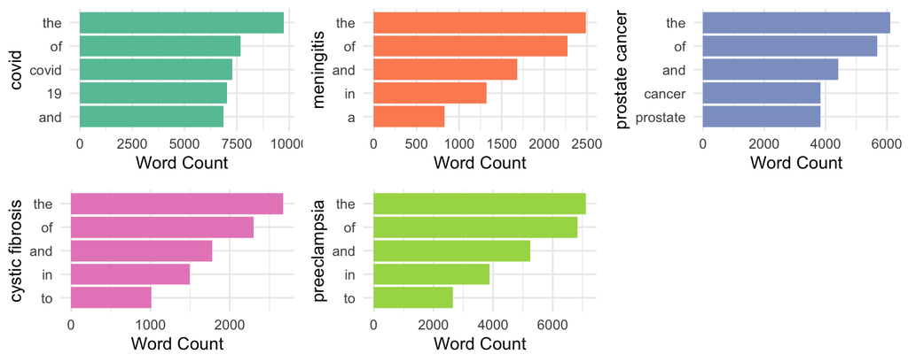

```r
plot_distribution <- function(term_name, term_color){
  df |>
    unnest_tokens(token, abstract) |>
    filter(term == term_name) |>
    count(token) |>
    top_n(5, n) |>
    ggplot(aes(n, fct_reorder(token, n))) +
    geom_col(fill = term_color[[term_name]]) +
    labs(x = "Word Count", y = term_name) +
    theme_minimal()
}

term_color <- setNames(RColorBrewer::brewer.pal(length(unique(df$term)), "Set2"), unique(df$term))

plot_list <- lapply(unique(df$term), plot_distribution, term_color)

main_plot <- plot_grid(
  plotlist = plot_list,
  ncol= 3
  )

plot_grid(
  plotlist = main_plot,
  ncol=1,
  label_size = 8,
  label_fontface = "bold",
  rel_heights = c(1, 0.1)
)
```

```r
rm(main_plot, plot_list, plot_distribution)
```

I didn’t really see anything interesting. The most common tokens are either stop words or disease names.

**Q2.** (15 points) Does removing stop words change what tokens appear as the most frequent? What are the 5 most common tokens for each search term after removing stop words?

```r
df |>
  unnest_tokens(token, abstract) |>
  group_by(term) |>
  anti_join(stop_words, by = c("token" = "word")) |>
  count(token) |>
  top_n(5, n) |>
  arrange(term, desc(n)) |>
  summarise(
    `Tokens (N)` = paste0(token, " (", n, ")", collapse = ", ")) |>
  ungroup() |>
  kable(align = "c",
        caption = "5 most common tokens for each search term (after removing stop words)")
```

5 most common tokens for each search term (after removing stop words)

| term | Tokens (N) |
| --- | --- |
| covid | covid (7275), 19 (7035), patients (2293), disease (943), pandemic (800) |
| cystic fibrosis | fibrosis (867), cystic (862), cf (625), patients (586), disease (400) |
| meningitis | patients (446), meningitis (429), meningeal (219), csf (206), clinical (187) |
| preeclampsia | pre (2038), eclampsia (2005), preeclampsia (1863), women (1196), pregnancy (969) |
| prostate cancer | cancer (3840), prostate (3832), patients (934), treatment (926), disease (652) |

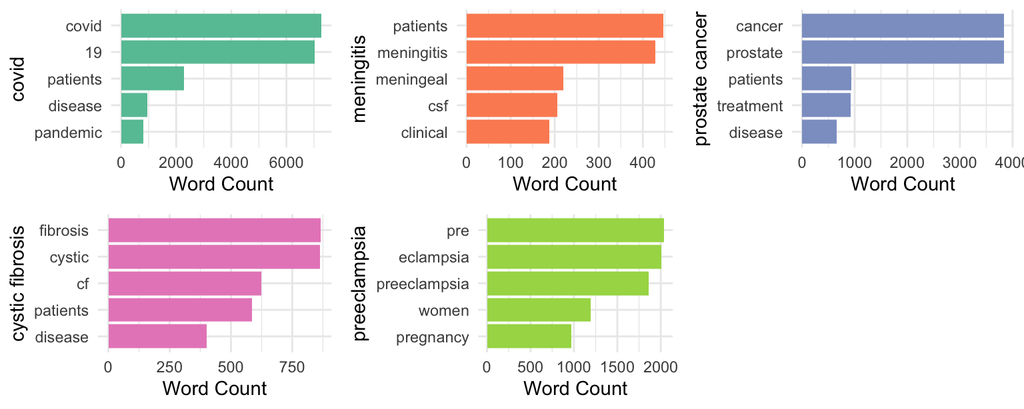

```r
plot_distribution <- function(term_name, term_color){
  df |>
    unnest_tokens(token, abstract) |>
    filter(term == term_name) |>
    anti_join(stop_words, by = c("token" = "word")) |>
    count(token) |>
    top_n(5, n) |>
    ggplot(aes(n, fct_reorder(token, n))) +
    geom_col(fill = term_color[[term_name]]) +
    labs(x = "Word Count", y = term_name) +
    theme_minimal()
}

plot_list <- lapply(unique(df$term), plot_distribution, term_color)

main_plot <- plot_grid(
  plotlist = plot_list,
  ncol= 3
  )

plot_grid(
  plotlist = main_plot,
  ncol=1,
  label_size = 8,
  label_fontface = "bold",
  rel_heights = c(1, 0.1)
)
```

```r
rm(main_plot, plot_list, plot_distribution)
```

Removing stop words changed the most frequent tokens.

**Q3.** (10 points) Tokenize the abstracts into bigrams. Find the 10 most common bigrams and visualize them.

```r
df |>
  unnest_ngrams(ngram, abstract, n = 2) |>
  count(term, ngram) |>
  group_by(term) |>
  top_n(10, n) |>
  arrange(term, desc(n)) |>
  summarise(
    `Tokens (N)` = paste0(ngram, " (", n, ")", collapse = ", ")) |>
  ungroup() |>
  kable(align = "c",
        caption = "10 most common bigrams")
```

10 most common bigrams

| term | Tokens (N) |
| --- | --- |
| covid | covid 19 (6969), of covid (1519), of the (1119), in the (943), patients with (718), the covid (706), with covid (576), 19 patients (442), 19 pandemic (419), to the (408) |
| cystic fibrosis | cystic fibrosis (859), of the (452), in the (319), with cystic (207), patients with (196), of cystic (168), fibrosis cf (160), and the (132), of cf (114), to the (107) |
| meningitis | of the (527), in the (332), patients with (163), and the (97), cerebrospinal fluid (88), is a (77), bacterial meningitis (76), to the (76), dura mater (67), year old (66) |
| preeclampsia | pre eclampsia (1854), in the (1004), of the (995), of pre (588), of preeclampsia (578), women with (452), is a (287), and the (283), associated with (279), for the (270) |
| prostate cancer | prostate cancer (3222), of prostate (870), in the (820), of the (790), patients with (340), cancer is (295), in prostate (294), and the (241), with prostate (229), for prostate (222) |

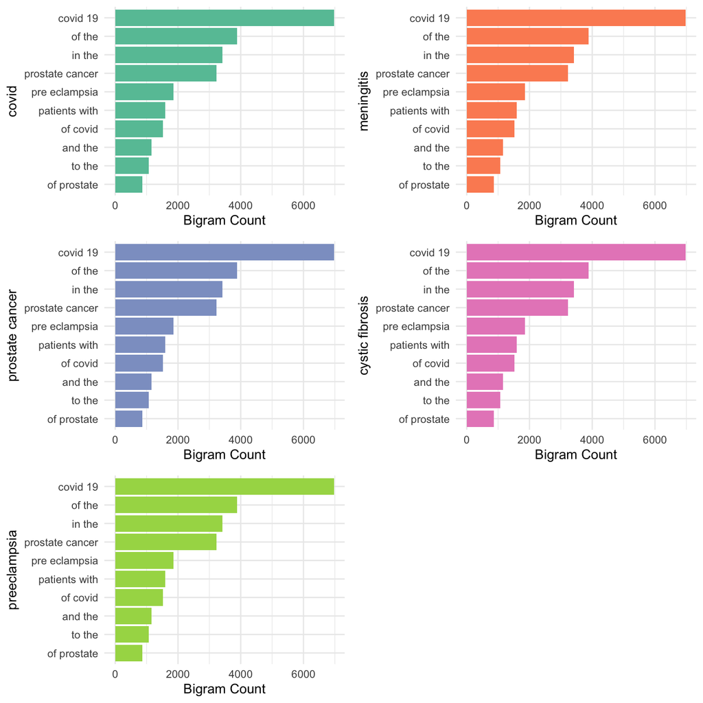

```r
plot_distribution <- function(term_name, term_color){
  df |>
    unnest_ngrams(ngram, abstract, n = 2) |>
    count(ngram) |>
    top_n(10, n) |>
    ggplot(aes(n, fct_reorder(ngram, n))) +
    geom_col(fill = term_color[[term_name]]) +
    labs(x = "Bigram Count", y = term_name) +
    theme_minimal()
}

plot_list <- lapply(unique(df$term), plot_distribution, term_color)

main_plot <- plot_grid(
  plotlist = plot_list,
  ncol= 2
  )

plot_grid(
  plotlist = main_plot,
  ncol=1,
  label_size = 8,
  label_fontface = "bold",
  rel_heights = c(1, 0.1)
)
```

```r
rm(main_plot, plot_list, plot_distribution)
```

Here, I noticed that some bigrams include stop words. Thus, I removed stop words before identifying bigrams:

```r
df |>
  unnest_tokens(token, abstract) |>
  group_by(term) |>
  anti_join(stop_words, by = c("token" = "word")) |>
  summarise(abstract = paste(token, collapse = " ")) |>
  unnest_ngrams(ngram, abstract, n = 2) |>
  count(term, ngram) |>
  group_by(term) |>
  top_n(10, n) |>
  arrange(term, desc(n)) |>
  summarise(
    `Tokens (N)` = paste0(ngram, " (", n, ")", collapse = ", ")) |>
  ungroup() |>
  kable(align = "c",
        caption = "10 most common bigrams after removing stop words")
```

10 most common bigrams after removing stop words

[output not shown]

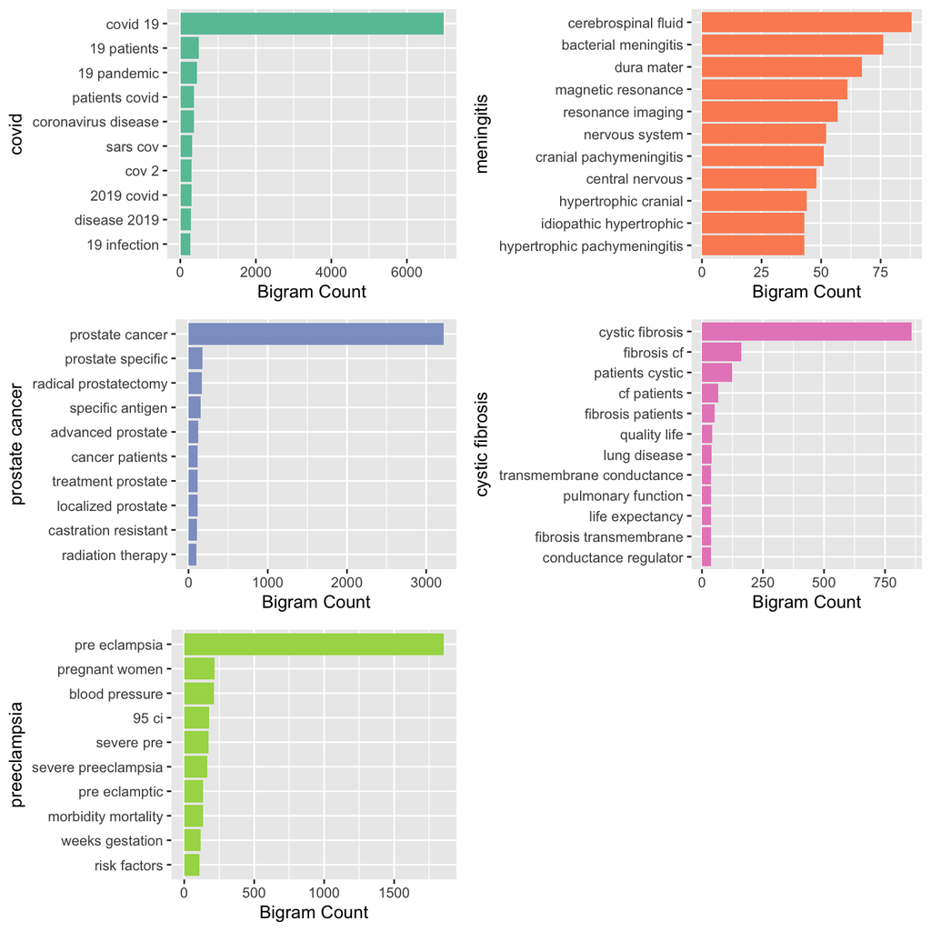

```r
plot_distribution <- function(term_name, term_color){
  df |>
    unnest_tokens(token, abstract) |>
    filter(term == term_name) |>
    anti_join(stop_words, by = c("token" = "word")) |>
    summarise(abstract = paste(token, collapse = " ")) |>
    unnest_ngrams(ngram, abstract, n = 2) |>
    count(ngram) |>
    top_n(10, n) |>
    ggplot(aes(n, fct_reorder(ngram, n))) +
    geom_col(fill = term_color[[term_name]]) +
    labs(x = "Bigram Count", y = term_name)
}

plot_list <- lapply(unique(df$term), plot_distribution, term_color)

main_plot <- plot_grid(
  plotlist = plot_list,
  ncol= 2
  )

plot_grid(
  plotlist = main_plot,
  ncol=1,
  label_size = 8,
  label_fontface = "bold",
  rel_heights = c(1, 0.1)
)
```

```r
rm(main_plot, plot_list, plot_distribution)
```

**Q4.** (20 points) Calculate the TF-IDF value for each word-search term combination (here you want the search term to be the “document”). What are the 5 tokens from each search term with the highest TF-IDF value? How are the results different from the answers you got in Question 1?

```r
kable(cbind(
  df |>
  unnest_tokens(token, abstract) |>
  count(term, token) |>
  bind_tf_idf(token, term, n) |>
  group_by(term) |>
  top_n(5, tf_idf) |>
  arrange(desc(tf_idf)) |>
  summarise(
    `Q4 Tokens (N; TF/IDF)` = paste0(token, " (", n, "; ", round(tf_idf, 5), ")", collapse = ", ")) |>
  ungroup() |>
  transmute(Q4_term = term,
            `Q4 Tokens (N; TF/IDF)`),
  df |>
  unnest_tokens(token, abstract) |>
  group_by(term) |>
  count(token) |>
  top_n(5, n) |>
  arrange(term, desc(n)) |>
  summarise(
    `Q1 Tokens (N)` = paste0(token, " (", n, ")", collapse = ", ")) |>
  ungroup() |>
  transmute(`Q1 Tokens (N)`)),
  align = "c",
  caption = "5 tokens from each search term with the highest TF-IDF value (Q4) vs 5 most frequent tokens from each seqrch term (Q1)")
```

5 tokens from each search term with the highest TF-IDF value (Q4) vs 5 most frequent tokens from each seqrch term (Q1)

| Q4_term | Q4 Tokens (N; TF/IDF) | Q1 Tokens (N) |
| --- | --- | --- |
| covid | covid (7275; 0.05972), pandemic (800; 0.00657), coronavirus (647; 0.00531), sars (372; 0.00305), cov (334; 0.00274) | the (9741), of (7668), covid (7275), 19 (7035), and (6861) |
| cystic fibrosis | cf (625; 0.01165), fibrosis (867; 0.00901), cystic (862; 0.00896), cftr (86; 0.00282), sweat (83; 0.00272) | the (2677), of (2304), and (1777), in (1497), to (1011) |
| meningitis | meningitis (429; 0.0148), meningeal (219; 0.00755), pachymeningitis (149; 0.00514), csf (206; 0.00405), meninges (106; 0.00366) | the (2489), of (2269), and (1683), in (1322), a (830) |
| preeclampsia | eclampsia (2005; 0.02298), preeclampsia (1863; 0.02135), pregnancy (969; 0.00353), maternal (797; 0.0029), gestational (191; 0.00219) | the (7119), of (6837), and (5255), in (3869), to (2651) |
| prostate cancer | prostate (3832; 0.0502), androgen (305; 0.004), psa (282; 0.00369), prostatectomy (215; 0.00282), castration (148; 0.00194) | the (6100), of (5682), and (4417), cancer (3840), prostate (3832) |

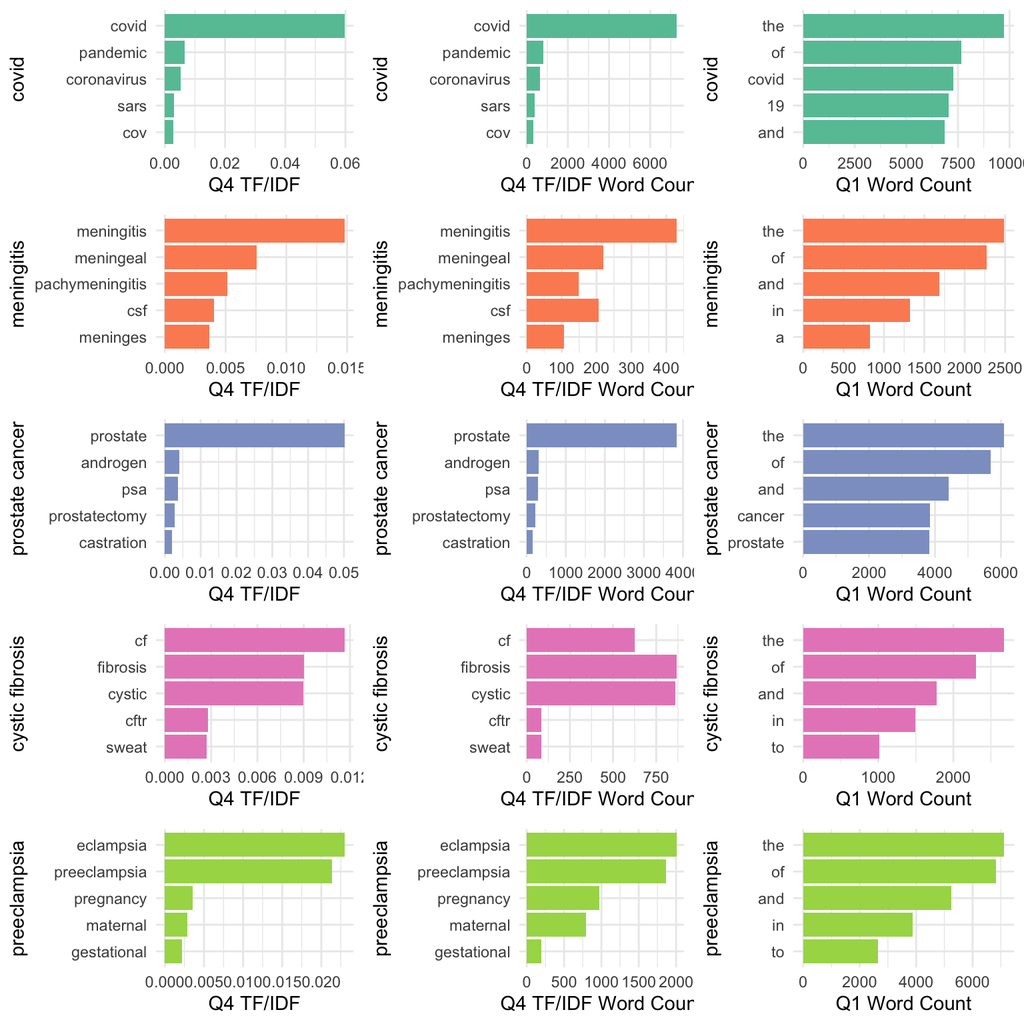

```r
plot_distribution <- function(term_name, term_color){
  df |>
    unnest_tokens(token, abstract) |>
    filter(term == term_name) |>
    count(token) |>
    top_n(5, n) |>
    ggplot(aes(n, fct_reorder(token, n))) +
    geom_col(fill = term_color[[term_name]]) +
    labs(x = "Q1 Word Count", y = term_name) +
    theme_minimal()
}

plot_distribution_tfidf <- function(term_name, term_color){
  df |>
    unnest_tokens(token, abstract) |>
    count(term, token) |>
    bind_tf_idf(token, term, n) |>
    group_by(term) |>
    top_n(5, tf_idf) |>
    arrange(desc(tf_idf)) |>
    ungroup() |>
    arrange(term) |>
    transmute(Q4_term = term,
              Q4_token = token,
              Q4_n = n,
              Q4_tf_idf = tf_idf) |>
    filter(Q4_term == term_name) |>
    ggplot(aes(x = Q4_tf_idf, y = fct_reorder(Q4_token, Q4_tf_idf))) +
    geom_col(fill = term_color[[term_name]]) +
    labs(x = "Q4 TF/IDF", y = term_name) +
    theme_minimal()
}

plot_distribution_tfidf_count <- function(term_name, term_color){
  df |>
    unnest_tokens(token, abstract) |>
    count(term, token) |>
    bind_tf_idf(token, term, n) |>
    group_by(term) |>
    top_n(5, tf_idf) |>
    arrange(desc(tf_idf)) |>
    ungroup() |>
    arrange(term) |>
    transmute(Q4_term = term,
              Q4_token = token,
              Q4_n = n,
              Q4_tf_idf = tf_idf) |>
    filter(Q4_term == term_name) |>
    ggplot(aes(x = Q4_n, y = fct_reorder(Q4_token, Q4_tf_idf))) +
    geom_col(fill = term_color[[term_name]]) +
    labs(x = "Q4 TF/IDF Word Count", y = term_name) +
    theme_minimal()
}

plot_list       <- lapply(unique(df$term), plot_distribution, term_color)
plot_list_tfidf <- lapply(unique(df$term), plot_distribution_tfidf, term_color)
plot_list_tfidf_count <- lapply(unique(df$term), plot_distribution_tfidf_count, term_color)


main_plot <- plot_grid(
  plotlist = plot_list,
  align = "v",
  ncol= 1
  )

main_plot_tfidf <- plot_grid(
  plotlist = plot_list_tfidf,
  align = "v",
  ncol= 1
  )

main_plot_tfidf_count <- plot_grid(
  plotlist = plot_list_tfidf_count,
  align = "v",
  ncol= 1
  )

plot_grid(
  plotlist = list(main_plot_tfidf, main_plot_tfidf_count, main_plot),
  align = "vh",
  ncol=3,
  label_size = 8,
  label_fontface = "bold",
  rel_widths = c(1.1, 1, 1)
)
```

```r
rm(main_plot, plot_list, plot_distribution, main_plot_tfidf, plot_list_tfidf, plot_distribution_tfidf, main_plot_tfidf_count, plot_list_tfidf_count, plot_distribution_tfidf_count)
```

Comparing to word count from Q1 (where tokens identified purely by word frequency), the tokens with highest TF/IDF are less frequent but more meaningful and search term specific.

## Sentiment Analysis

**Q5.** (20 points) Perform a sentiment analysis using the NRC lexicon. What is the most common sentiment for each search term? What if you remove `"positive"` and `"negative"` from the list?s

```r
df |>
  unnest_tokens(token, abstract) |>
  inner_join(get_sentiments("nrc"), by = c("token" = "word")) |>
  group_by(term, sentiment) |>
  summarise(n = n()) |>
  ungroup() |>
  group_by(term) |>
  top_n(1, n) |>
  arrange(desc(n)) |>
  ungroup() |>
  kable(align = "c",
        caption = "Most common sentiment for each search term")
```

Most common sentiment for each search term

| term | sentiment | n |
| --- | --- | --- |
| covid | positive | 9874 |
| prostate cancer | negative | 8918 |
| preeclampsia | positive | 8014 |
| cystic fibrosis | positive | 2747 |
| meningitis | negative | 2109 |

```r
df |>
  unnest_tokens(token, abstract) |>
  inner_join(get_sentiments("nrc") |>
               filter(sentiment != "positive" & sentiment != "negative" ),
             by = c("token" = "word")) |>
  group_by(term, sentiment) |>
  summarise(n = n()) |>
  ungroup() |>
  group_by(term) |>
  top_n(1, n) |>
  arrange(desc(n)) |>
  ungroup() |>
  kable(align = "c",
        caption = "Most common sentiment for each search term after removing 'positive' and 'negative'")
```

Most common sentiment for each search term after removing ‘positive’ and ‘negative’

| term | sentiment | n |
| --- | --- | --- |
| prostate cancer | fear | 8118 |
| covid | fear | 7730 |
| preeclampsia | anticipation | 4780 |
| cystic fibrosis | disgust | 1714 |
| meningitis | fear | 1510 |

**Q6.** (20 points) Now perform a sentiment analysis using the AFINN lexicon to get an average positivity score for each abstract (hint: you may want to create a variable that indexes, or counts, the abstracts). Create a visualization that shows these scores grouped by search term. Are any search terms noticeably different from the others?

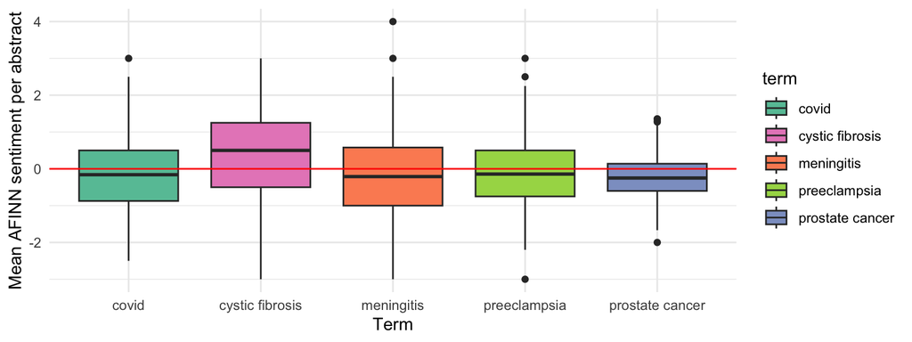

```r
ggplot(
  df |>
    mutate(abstract_id = row_number()) %>%
    unnest_tokens(token, abstract) |>
    inner_join(get_sentiments("afinn"), by = c("token" = "word")) |>
    group_by(term, abstract_id) |>
    summarise(mean_sentiment = mean(value),
              sd_sentiment = sd(value)) |>
    ungroup(),
  aes(x = term, y = mean_sentiment, fill = term)) +
  geom_boxplot() +
  geom_hline(yintercept = 0, color = "red", linewidth = 0.5) +
  scale_fill_manual(values = term_color) +
  labs(x = "Term", y = "Mean AFINN sentiment per abstract") +
  theme_minimal()
```

Cystic fibrosis search term shows a positive mean AFINN score, while other search terms have negative mean AFINN score.

The result here is not consistent with the previous finding, where the most common sentiment was anticipation for preeclampsia and disgust for cystic fibrosis. This discrepancy is likely because, instead of calculating average AFINN score for each abstract, the previous analysis summed the total sentiment across all abstracts .